# Sequence and shape correlation: 4 replicates

Paulina Dziubanska-Kusibab

30 March, 2020 18:21:14

```r
rm(list=ls())
library(ggplot2)
library(readxl)
library(reshape2)
library(DNAshapeR)
library(data.table)
library(dplyr)
library(seqRFLP)
library(Biostrings)
```

# 1 Introduction

Here we would like to correlate identified sequence enrichments in DSBs flanking regions of colibactin-induced breaks (+/7nt) with DNA shape parameters.  
Normalized logRatios for hexanucleotides of 4 replicates and information whether hexanucleotide is associated with barcode or not, are being imported.

Please note that for this enrichment analysis, presence of the motif within extracted sequence was counted in **yes:no** system - even if the hexanucleotide was present more than once it was only counted once.

For MGW, EP and ProT - central two values are averaged and used for the correlation **xxV3V4xx**

For Roll, HelT and Stiffness - central three values are averaged and used **xV2V3V4x**

Values of Stiffness for tetranucleotides were provided by Federica Barristini (IRB Barcelona). Next for each hexanucleotide three tetranucleotides were assigned and values for them were averaged or maximal/minimal value was taken (it is stated in the text).

```r
load("../../Data/Shape_correlations/ShapePrediction/Hexanucleotide_Shape_and_Enrichment.Rdata")
```

```r
library(ggthemes)
```

## 1.1 Correlations for hexanucleotides (avg.DNAShape.value) not associated with barcode sequences

```r
lr_shape_noBC <- lr_shape[lr_shape$bc=="no BC"]
lr_shape_noBC[, label:=ifelse(Nt %in% c("AAAATT","AAATTT","AATATT"), as.character(Nt), "")]
lr_shape_noBC[, class:=ifelse(Nt %in% c("AAAATT","AAATTT","AATATT"), "AAWWTT", "other")]
```

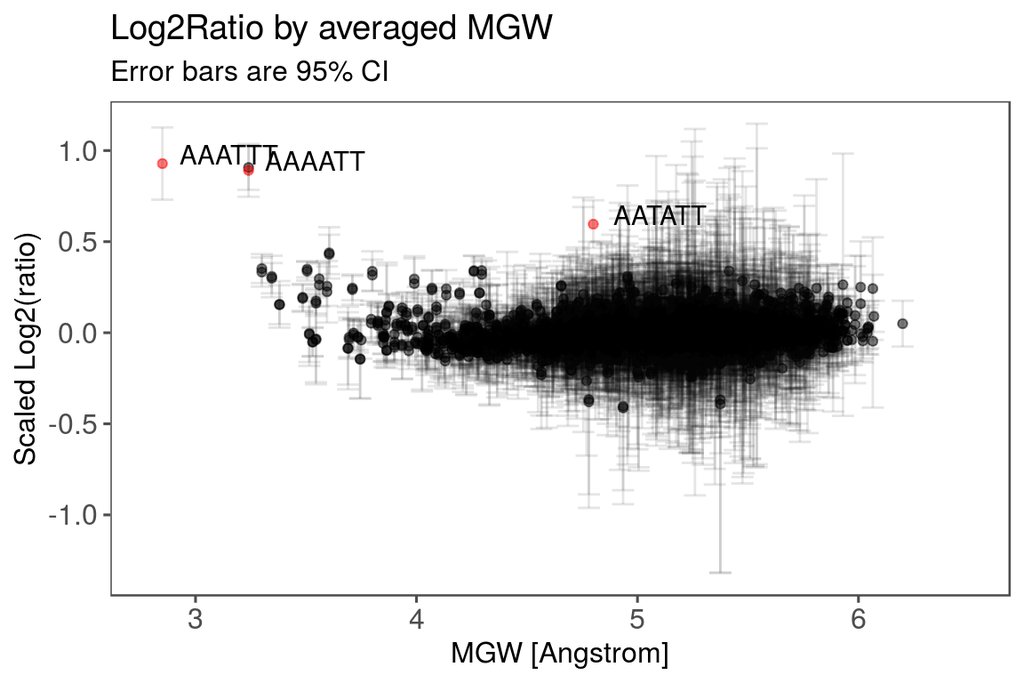

```r
x_var = "MGW.avgV3V4"
x_var_label = "MGW [Angstrom]"
x_var_name = unlist(sapply(strsplit(x_var, "\\."), `[`,1))
p = ggplot(lr_shape_noBC, aes_string(x=x_var, y="Mean", group="Nt")) +
  geom_point(alpha=0.52, aes(col=class)) +
  geom_errorbar(width=.1, aes(ymin=Mean-CI, ymax=Mean+CI), colour="black", alpha=0.1) +
  labs(x=x_var_label, y="Scaled Log2(ratio)") + theme_few()+ theme(axis.text = element_text(size=12), legend.position="none") +
  geom_text(aes(label=label), nudge_x=0.3, nudge_y=0.05) +
  scale_color_manual(values = c("AAWWTT"="red","other"="black"))

print(p + labs(title=paste0("Log2Ratio by averaged ",x_var_name ), subtitle = "Error bars are 95% CI") )
```

```r
pdf(file=paste0("../../Results/3_DSB-shape-characteristics/Log2Ratio_vs_Mean_",x_var_name,"_HN_no_BC.pdf"), width = 6, height = 4)
print(p)
dev.off()
```

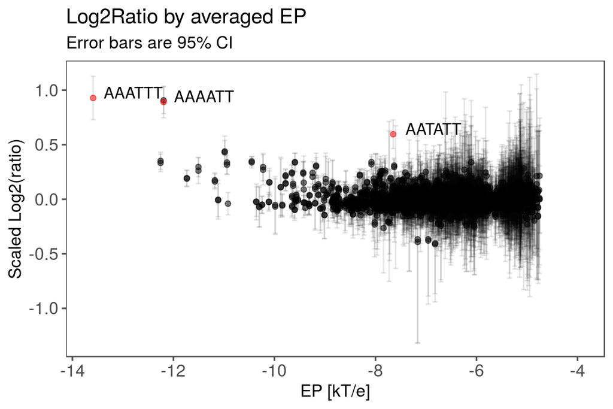

```r
x_var = "EP.avgV3V4"
x_var_label = "EP [kT/e]"
x_var_name = unlist(sapply(strsplit(x_var, "\\."), `[`,1))
p = ggplot(lr_shape_noBC, aes_string(x=x_var, y="Mean", group="Nt")) +
  geom_point(alpha=0.52, aes(col=class)) +
  geom_errorbar(width=.1, aes(ymin=Mean-CI, ymax=Mean+CI), colour="black", alpha=0.1) +
  labs(x=x_var_label, y="Scaled Log2(ratio)") + theme_few()+ theme(axis.text = element_text(size=12), legend.position="none") +
  geom_text(aes(label=label), nudge_x=0.8, nudge_y=0.05) +
  scale_color_manual(values = c("AAWWTT"="red","other"="black"))

print(p + labs(title=paste0("Log2Ratio by averaged ",x_var_name ), subtitle = "Error bars are 95% CI") )
```

```r
pdf(file=paste0("../../Results/3_DSB-shape-characteristics/Log2Ratio_vs_Mean_",x_var_name,"_HN_no_BC.pdf"), width = 6, height = 4)
print(p)
dev.off()
```

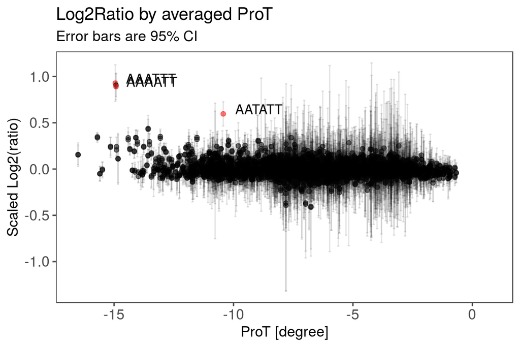

```r
x_var = "ProT.avgV3V4"
x_var_label = "ProT [degree]"
x_var_name = unlist(sapply(strsplit(x_var, "\\."), `[`,1))
p = ggplot(lr_shape_noBC, aes_string(x=x_var, y="Mean", group="Nt")) +
  geom_point(alpha=0.52, aes(col=class)) +
  geom_errorbar(width=.1, aes(ymin=Mean-CI, ymax=Mean+CI), colour="black", alpha=0.1) +
  labs(x=x_var_label, y="Scaled Log2(ratio)") + theme_few()+ theme(axis.text = element_text(size=12), legend.position="none") +
  geom_text(aes(label=label), nudge_x=1.5, nudge_y=0.05) +
  scale_color_manual(values = c("AAWWTT"="red","other"="black"))

print(p + labs(title=paste0("Log2Ratio by averaged ",x_var_name ), subtitle = "Error bars are 95% CI") )
```